# Course Project 2 - PM2.5

Davide

Thursday, August 21, 2014

Set up the environment:

```r
rm(list = ls())
setwd('C:/Nuova cartella/Exploratory Data Analysis/Course Project 2 - PM2.5')
```

Read the two data sets into dataframe objects:

```r
NEI = readRDS("summarySCC_PM25.rds")
str(NEI)
```

```
## 'data.frame':    6497651 obs. of  6 variables:
##  $ fips     : chr  "09001" "09001" "09001" "09001" ...
##  $ SCC      : chr  "10100401" "10100404" "10100501" "10200401" ...
##  $ Pollutant: chr  "PM25-PRI" "PM25-PRI" "PM25-PRI" "PM25-PRI" ...
##  $ Emissions: num  15.714 234.178 0.128 2.036 0.388 ...
##  $ type     : chr  "POINT" "POINT" "POINT" "POINT" ...
##  $ year     : int  1999 1999 1999 1999 1999 1999 1999 1999 1999 1999 ...
```

```r
head(NEI)
```

```
##     fips      SCC Pollutant Emissions  type year
## 4  09001 10100401  PM25-PRI    15.714 POINT 1999
## 8  09001 10100404  PM25-PRI   234.178 POINT 1999
## 12 09001 10100501  PM25-PRI     0.128 POINT 1999
## 16 09001 10200401  PM25-PRI     2.036 POINT 1999
## 20 09001 10200504  PM25-PRI     0.388 POINT 1999
## 24 09001 10200602  PM25-PRI     1.490 POINT 1999
```

```r
SCC = readRDS("Source_Classification_Code.rds")
str(SCC)
```

```
## 'data.frame':    11717 obs. of  15 variables:
##  $ SCC                : Factor w/ 11717 levels "10100101","10100102",..: 1 2 3 4 5 6 7 8 9 10 ...
##  $ Data.Category      : Factor w/ 6 levels "Biogenic","Event",..: 6 6 6 6 6 6 6 6 6 6 ...
##  $ Short.Name         : Factor w/ 11238 levels "","2,4-D Salts and Esters Prod /Process Vents, 2,4-D Recovery: Filtration",..: 3283 3284 3293 3291 3290 3294 3295 3296 3292 3289 ...
##  $ EI.Sector          : Factor w/ 59 levels "Agriculture - Crops & Livestock Dust",..: 18 18 18 18 18 18 18 18 18 18 ...
##  $ Option.Group       : Factor w/ 25 levels "","C/I Kerosene",..: 1 1 1 1 1 1 1 1 1 1 ...
##  $ Option.Set         : Factor w/ 18 levels "","A","B","B1A",..: 1 1 1 1 1 1 1 1 1 1 ...
##  $ SCC.Level.One      : Factor w/ 17 levels "Brick Kilns",..: 3 3 3 3 3 3 3 3 3 3 ...
##  $ SCC.Level.Two      : Factor w/ 146 levels "","Agricultural Chemicals Production",..: 32 32 32 32 32 32 32 32 32 32 ...
##  $ SCC.Level.Three    : Factor w/ 1061 levels "","100% Biosolids (e.g., sewage sludge, manure, mixtures of these matls)",..: 88 88 156 156 156 156 156 156 156 156 ...
##  $ SCC.Level.Four     : Factor w/ 6084 levels "","(NH4)2 SO4 Acid Bath System and Evaporator",..: 4455 5583 4466 4458 1341 5246 5584 5983 4461 776 ...
##  $ Map.To             : num  NA NA NA NA NA NA NA NA NA NA ...
##  $ Last.Inventory.Year: int  NA NA NA NA NA NA NA NA NA NA ...
##  $ Created_Date       : Factor w/ 57 levels "","1/27/2000 0:00:00",..: 1 1 1 1 1 1 1 1 1 1 ...
##  $ Revised_Date       : Factor w/ 44 levels "","1/27/2000 0:00:00",..: 1 1 1 1 1 1 1 1 1 1 ...
##  $ Usage.Notes        : Factor w/ 21 levels ""," ","includes bleaching towers, washer hoods, filtrate tanks, vacuum pump exhausts",..: 1 1 1 1 1 1 1 1 1 1 ...
```

```r
head(SCC)
```

```
##        SCC Data.Category
## 1 10100101         Point
## 2 10100102         Point
## 3 10100201         Point
## 4 10100202         Point
## 5 10100203         Point
## 6 10100204         Point
##                                                                   Short.Name
## 1                   Ext Comb /Electric Gen /Anthracite Coal /Pulverized Coal
## 2 Ext Comb /Electric Gen /Anthracite Coal /Traveling Grate (Overfeed) Stoker
## 3       Ext Comb /Electric Gen /Bituminous Coal /Pulverized Coal: Wet Bottom
## 4       Ext Comb /Electric Gen /Bituminous Coal /Pulverized Coal: Dry Bottom
## 5                   Ext Comb /Electric Gen /Bituminous Coal /Cyclone Furnace
## 6                   Ext Comb /Electric Gen /Bituminous Coal /Spreader Stoker
##                                EI.Sector Option.Group Option.Set
```

[output cut: 34 more lines]

## Question #1

*Have total emissions from PM2.5 decreased in the United States from 1999 to 2008?*

Using the base plotting system, make a plot showing the total PM2.5 emission from all sources for each of the years 1999, 2002, 2005, and 2008

```r
# Totalize Emissions per each year
total_emissions_per_year <- with(NEI,  tapply(Emissions, year, sum, na.dm = TRUE))
str(total_emissions_per_year)
```

```
##  num [1:4(1d)] 7332968 5635781 5454704 3464207
##  - attr(*, "dimnames")=List of 1
##   ..$ : chr [1:4] "1999" "2002" "2005" "2008"
```

```r
total_emissions_per_year
```

```
##    1999    2002    2005    2008
## 7332968 5635781 5454704 3464207
```

```r
names(total_emissions_per_year)
```

```
## [1] "1999" "2002" "2005" "2008"
```

```r
# Get labels for plot labelling
years_range = range(NEI$year)
str(years_range)
```

```
##  int [1:2] 1999 2008
```

```r
years_range_character = as.character(years_range)

main <- paste('Total US PM 2.5 Emissions\n', years_range_character[1], 'to', years_range_character[2], sep = ' ')
main
```

```
## [1] "Total US PM 2.5 Emissions\n 1999 to 2008"
```

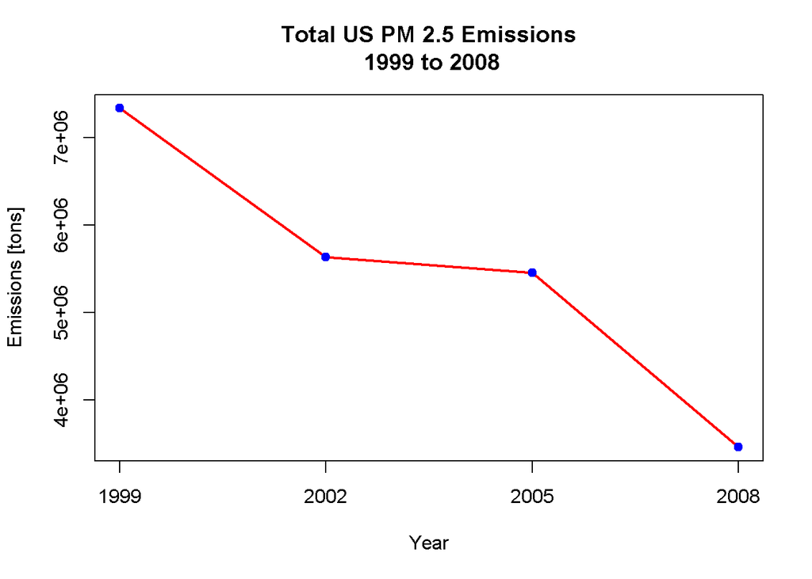

```r
# Plot total emissions vs year
plot(names(total_emissions_per_year), total_emissions_per_year, col = 'red', lwd = 2, type = 'l', xlab = 'Year', ylab = 'Emissions [tons]', main = main, xaxt = 'n')
axis(side = 1, at = names(total_emissions_per_year), labels = names(total_emissions_per_year))
points(names(total_emissions_per_year), total_emissions_per_year, pch = 19, col = 'blue')
```

## Question #2

*Have total emissions from PM2.5 decreased in the Baltimore City, Maryland (fips == “24510”) from 1999 to 2008?*

Use the base plotting system to make a plot answering this question.

```r
NEI_baltimore <- subset(NEI, NEI$fips == '24510')

total_emissions_per_year_baltimore <- with(NEI_baltimore,  tapply(Emissions, year, sum, na.dm = TRUE))

str(total_emissions_per_year_baltimore)
```

```
##  num [1:4(1d)] 3275 2455 3092 1863
##  - attr(*, "dimnames")=List of 1
##   ..$ : chr [1:4] "1999" "2002" "2005" "2008"
```

```r
total_emissions_per_year_baltimore
```

```
## 1999 2002 2005 2008
## 3275 2455 3092 1863
```

```r
names(total_emissions_per_year_baltimore)
```

```
## [1] "1999" "2002" "2005" "2008"
```

```r
years_range_baltimore = range(NEI_baltimore$year)
str(years_range_baltimore)
```

```
##  int [1:2] 1999 2008
```

```r
years_range__baltimore_character = as.character(years_range_baltimore)

main <- paste('PM 2.5 Emissions\n', 'Baltimore City, MD,', years_range__baltimore_character[1], 'to', years_range__baltimore_character[2], sep = ' ')
main
```

```
## [1] "PM 2.5 Emissions\n Baltimore City, MD, 1999 to 2008"
```

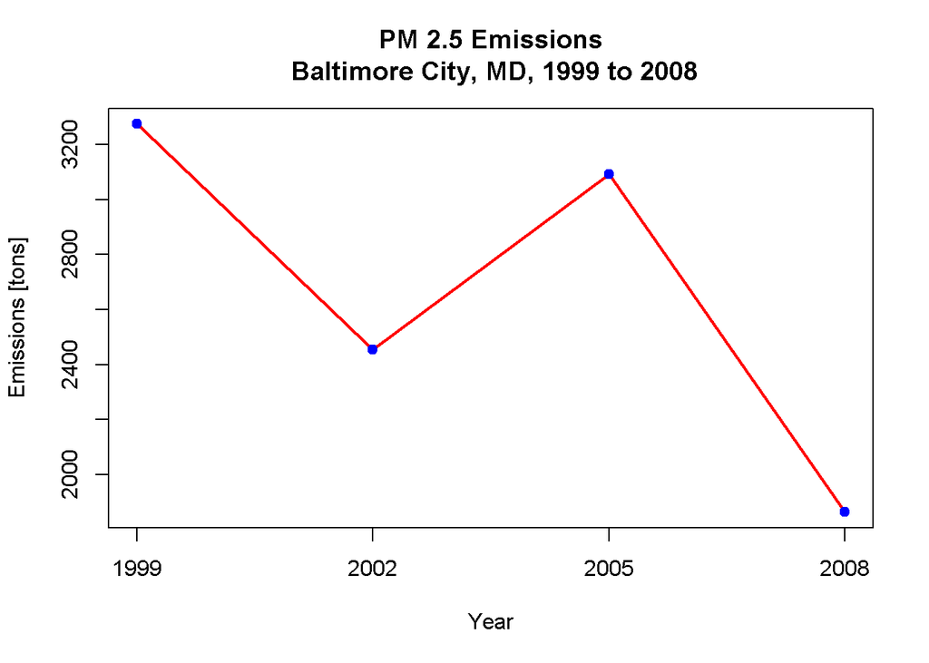

```r
plot(names(total_emissions_per_year_baltimore), total_emissions_per_year_baltimore, col = 'red', lwd = 2, type = 'l', xlab = 'Year', ylab = 'Emissions [tons]', main = main, xaxt = 'n')
axis(side = 1, at = names(total_emissions_per_year_baltimore), labels = names(total_emissions_per_year_baltimore))
points(names(total_emissions_per_year_baltimore), total_emissions_per_year_baltimore, pch = 19, col = 'blue')
```

## Question #3

*Of the four types of sources indicated by the type (point, nonpoint, onroad, nonroad) variable, which of these four sources have seen decreases in emissions from 1999-2008 for Baltimore City? Which have seen increases in emissions from 1999-2008?*

Use the ggplot2 plotting system to make a plot answer this question.

```r
#install.packages('ggplot2')

require('ggplot2')
library(ggplot2)
```

```r
NEI_baltimore_type <- split(NEI_baltimore, NEI_baltimore$type)
str(NEI_baltimore_type)
```

```
## List of 4
##  $ NON-ROAD:'data.frame':    416 obs. of  6 variables:
##   ..$ fips     : chr [1:416] "24510" "24510" "24510" "24510" ...
##   ..$ SCC      : chr [1:416] "2260003030" "2260003040" "2260004016" "2260004021" ...
##   ..$ Pollutant: chr [1:416] "PM25-PRI" "PM25-PRI" "PM25-PRI" "PM25-PRI" ...
##   ..$ Emissions: num [1:416] 0.03 0 0.16 2.75 1.62 1.73 1.74 0 0.23 1.66 ...
##   ..$ type     : chr [1:416] "NON-ROAD" "NON-ROAD" "NON-ROAD" "NON-ROAD" ...
##   ..$ year     : int [1:416] 1999 1999 1999 1999 1999 1999 1999 1999 1999 1999 ...
##  $ NONPOINT:'data.frame':    142 obs. of  6 variables:
##   ..$ fips     : chr [1:142] "24510" "24510" "24510" "24510" ...
##   ..$ SCC      : chr [1:142] "2102004000" "2102005000" "2103002000" "2103004000" ...
##   ..$ Pollutant: chr [1:142] "PM25-PRI" "PM25-PRI" "PM25-PRI" "PM25-PRI" ...
##   ..$ Emissions: num [1:142] 7.19 55.39 1.03 37.42 5.21 ...
##   ..$ type     : chr [1:142] "NONPOINT" "NONPOINT" "NONPOINT" "NONPOINT" ...
##   ..$ year     : int [1:142] 1999 1999 1999 1999 1999 1999 1999 1999 1999 1999 ...
##  $ ON-ROAD :'data.frame':    1119 obs. of  6 variables:
##   ..$ fips     : chr [1:1119] "24510" "24510" "24510" "24510" ...
##   ..$ SCC      : chr [1:1119] "220100123B" "220100123T" "220100123X" "220100125B" ...
##   ..$ Pollutant: chr [1:1119] "PM25-PRI" "PM25-PRI" "PM25-PRI" "PM25-PRI" ...
##   ..$ Emissions: num [1:1119] 7.38 2.78 11.76 3.5 1.32 ...
##   ..$ type     : chr [1:1119] "ON-ROAD" "ON-ROAD" "ON-ROAD" "ON-ROAD" ...
##   ..$ year     : int [1:1119] 1999 1999 1999 1999 1999 1999 1999 1999 1999 1999 ...
##  $ POINT   :'data.frame':    419 obs. of  6 variables:
##   ..$ fips     : chr [1:419] "24510" "24510" "24510" "24510" ...
##   ..$ SCC      : chr [1:419] "10100601" "10200601" "10200602" "30100699" ...
##   ..$ Pollutant: chr [1:419] "PM25-PRI" "PM25-PRI" "PM25-PRI" "PM25-PRI" ...
##   ..$ Emissions: num [1:419] 6.53 78.88 0.92 10.38 10.86 ...
##   ..$ type     : chr [1:419] "POINT" "POINT" "POINT" "POINT" ...
##   ..$ year     : int [1:419] 1999 1999 1999 1999 1999 1999 1999 1999 1999 1999 ...
```

```r
summary(NEI_baltimore_type)
```

```
##          Length Class      Mode
## NON-ROAD 6      data.frame list
## NONPOINT 6      data.frame list
## ON-ROAD  6      data.frame list
## POINT    6      data.frame list
```

```r
names <- c()
df <- NULL
for (i in 1:length(NEI_baltimore_type)) {

  name <- unique(NEI_baltimore_type[[i]]$type)
  name <- paste('Emissions', name, sep = '.')
  name <- gsub('-', '_', name)
  names <- c(names, name)

  v1 <- with(NEI_baltimore_type[[i]], tapply(Emissions, year, sum, na.dm = TRUE))
  years <- names(v1)
  v1 <- unname(v1)

  types <- rep(name, times = 4)

  print(years)
  print(v1)
  print(types)

  df1 <- data.frame(year = years, Emissions = v1, type = types)
  print(df)
  print(df1)
  if (is.null(df))
    df = df1
  else
    df <- rbind(df, df1)

}
```

```
## [1] "1999" "2002" "2005" "2008"
## [1] 523.94 241.85 249.93  56.82
## [1] "Emissions.NON_ROAD" "Emissions.NON_ROAD" "Emissions.NON_ROAD"
## [4] "Emissions.NON_ROAD"
## NULL
##   year Emissions               type
## 1 1999    523.94 Emissions.NON_ROAD
## 2 2002    241.85 Emissions.NON_ROAD
## 3 2005    249.93 Emissions.NON_ROAD
## 4 2008     56.82 Emissions.NON_ROAD
## [1] "1999" "2002" "2005" "2008"
## [1] 2109 1510 1510 1374
## [1] "Emissions.NONPOINT" "Emissions.NONPOINT" "Emissions.NONPOINT"
## [4] "Emissions.NONPOINT"
##   year Emissions               type
```

[output cut: 48 more lines]

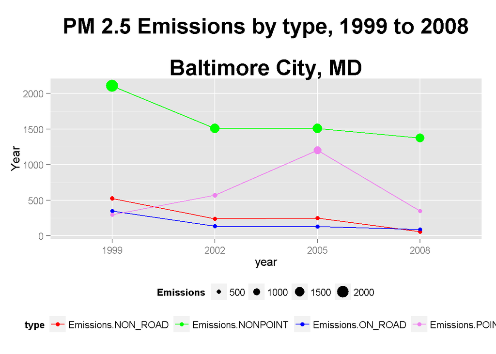

```r
Palette1 <- c('red','green','blue','violet','black')

ggplot(df, aes(year, Emissions, colour = type)) +
geom_point() +
geom_point(aes(size = Emissions)) +
scale_colour_manual(values = Palette1) +
geom_line(aes(group = factor(df$type))) +
theme(legend.position = 'bottom', plot.title = element_text(lineheight = 1.6, face = 'bold', size = 22)) +
ylab('Emissions [ton]') +
ylab('Year') +
ggtitle('PM 2.5 Emissions by type, 1999 to 2008\nBaltimore City, MD')
```

## Question #4

*Across the United States, how have emissions from coal combustion-related sources changed from 1999-2008?*

The strategy I’ll use to extract the emissions of coal related sources is ad follows:

- Using a regular expression (`.*[cC]oal.*`) we’ll match the values of SCC’s EI.Sector columns that are coal-related. The reg exp means:
- “.*" – matches any number (“*“) of any characters (”.“). Read it as”any character (.) as many times (*) as you’d like”
- “[cC]” – matches either the lowercase “c” or uppercase “C” just once
- “oal” – matches exactly that series of characters
- “.*" – matches any character.
- the corresponding values of SCC are extracted;
- these values are then compared with NEI’s SCC columns and matching rows are selected.

Let’s see this in action:

```r
coal_related_EI.Sectors <- unique(grep('.*[cC]oal.*', SCC$EI.Sector, ignore.case = TRUE, value = TRUE))
coal_related <- SCC$EI.Sector %in% coal_related_EI.Sectors
length(coal_related)
```

```
## [1] 11717
```

```r
head(coal_related)
```

```
## [1] TRUE TRUE TRUE TRUE TRUE TRUE
```

```r
sum(coal_related)
```

```
## [1] 99
```

```r
coal_related_SCC <- SCC[coal_related, ]$SCC
NEI_coal_related <- NEI[NEI$SCC %in% coal_related_SCC, ]
head(NEI_coal_related)
```

```
##        fips        SCC Pollutant Emissions     type year
## 9979  09011   10100217  PM25-PRI   479.907    POINT 1999
## 15882 23001 2102001000  PM25-PRI     0.054 NONPOINT 1999
## 15892 23001 2103002000  PM25-PRI     0.231 NONPOINT 1999
## 17790 23003 2102001000  PM25-PRI     0.032 NONPOINT 1999
## 17800 23003 2103002000  PM25-PRI     0.194 NONPOINT 1999
## 19504 23005   10200202  PM25-PRI     0.119    POINT 1999
```

```r
dim(NEI_coal_related)
```

```
## [1] 28480     6
```

A little bit of consistency check is worthwile:

```r
sum(unique(NEI_coal_related$SCC) %in% coal_related_SCC)
```

```
## [1] 80
```

```r
total_emissions_per_year <- with(NEI_coal_related,  tapply(Emissions, year, sum, na.dm = TRUE))
total_emissions_per_year
```

```
##   1999   2002   2005   2008
## 572128 546790 552882 343433
```

```r
years_range = range(NEI$year)
str(years_range)
```

```
##  int [1:2] 1999 2008
```

```r
years_range_character = as.character(years_range)

main <- paste('US PM 2.5 Emissions\n', 'Coal-related, ', years_range_character[1], 'to', years_range_character[2], sep = ' ')
main
```

```
## [1] "US PM 2.5 Emissions\n Coal-related,  1999 to 2008"
```

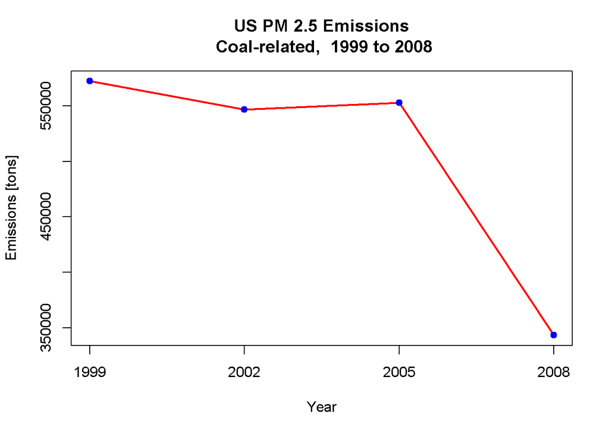

```r
# Plot total emissions vs year
plot(names(total_emissions_per_year), total_emissions_per_year, col = 'red', lwd = 2, type = 'l', xlab = 'Year', ylab = 'Emissions [tons]', main = main, xaxt = 'n')
axis(side = 1, at = names(total_emissions_per_year), labels = names(total_emissions_per_year))
points(names(total_emissions_per_year), total_emissions_per_year, pch = 19, col = 'blue')
```

## Question #5

*How have emissions from motor vehicle sources changed from 1999-2008 in Baltimore City?*

I’ll use the solving procedure of Question #4, changing the regular expression to `.*[vV]ehicles*`.

```r
vehicles_related_EI.Sectors <- unique(grep('.*[vV]ehicles*', SCC$EI.Sector, ignore.case = TRUE, value = TRUE))
vehicles_related <- SCC$EI.Sector %in% vehicles_related_EI.Sectors
vehicles_related_SCC <- SCC[vehicles_related, ]$SCC
NEI_vehicles_related <- NEI[NEI$SCC %in% vehicles_related_SCC, ]
```

Question ask for vehicles emissions for Baltimore City, MD only, so we have an additional subsetting step to perform:

```r
NEI_vehicles_related_baltimore <- NEI[NEI_vehicles_related$fips == '24510', ]
dim(NEI_vehicles_related_baltimore)
```

```
## [1] 2430    6
```

Now we can proceed with as before:

```r
total_emissions_per_year <- with(NEI_vehicles_related_baltimore,  tapply(Emissions, year, sum, na.dm = TRUE))
total_emissions_per_year
```

```
##    1999    2002    2005    2008
## 1434.48  251.49   66.84 4785.12
```

```r
years_range = range(NEI$year)
str(years_range)
```

```
##  int [1:2] 1999 2008
```

```r
years_range_character = as.character(years_range)

main <- paste('Baltimore City, MD PM 2.5 Emissions\n', 'Vehicle-related, ', years_range_character[1], 'to', years_range_character[2], sep = ' ')
main
```

```
## [1] "Baltimore City, MD PM 2.5 Emissions\n Vehicle-related,  1999 to 2008"
```

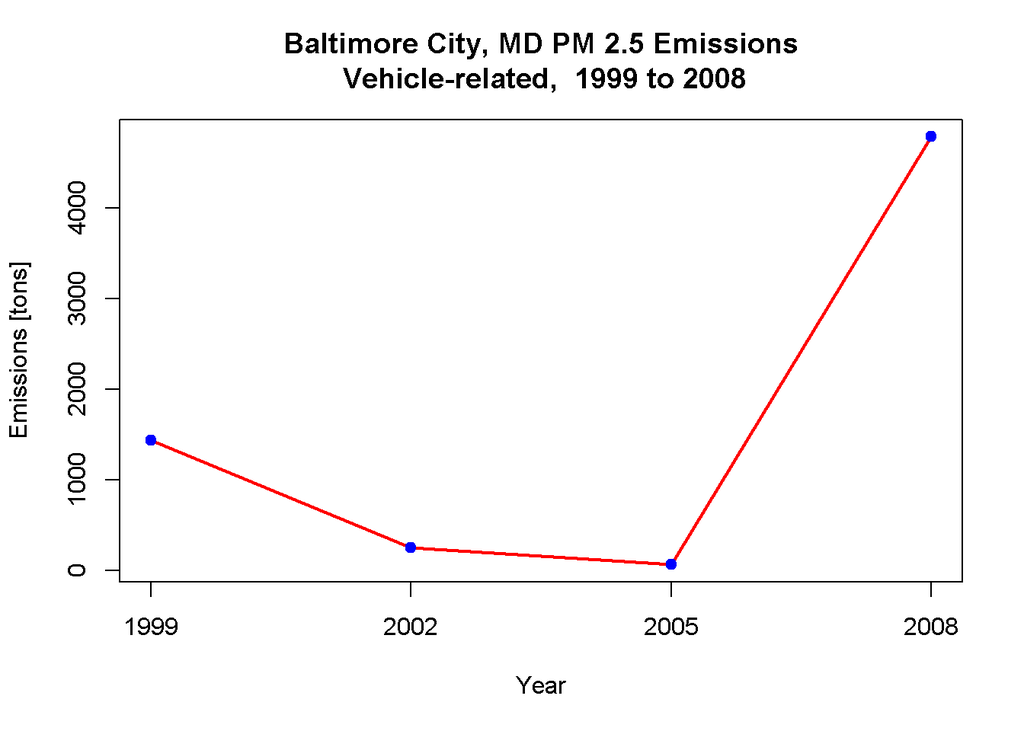

```r
# Plot total emissions vs year
plot(names(total_emissions_per_year), total_emissions_per_year, col = 'red', lwd = 2, type = 'l', xlab = 'Year', ylab = 'Emissions [tons]', main = main, xaxt = 'n')
axis(side = 1, at = names(total_emissions_per_year), labels = names(total_emissions_per_year))
points(names(total_emissions_per_year), total_emissions_per_year, pch = 19, col = 'blue')
```

## Question #6

*Compare emissions from motor vehicle sources in Baltimore City with emissions from motor vehicle sources in Los Angeles County, California (fips == “06037”). Which city has seen greater changes over time in motor vehicle emissions?*

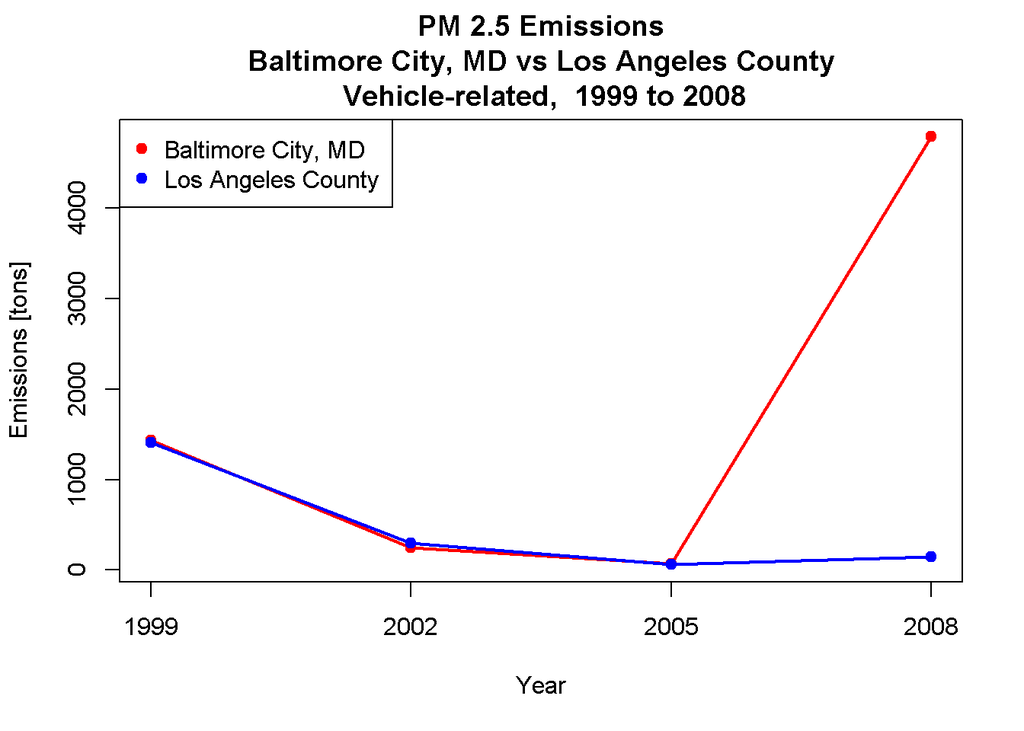

```r
NEI_vehicles_related_losangeles <- NEI[NEI_vehicles_related$fips == '06037', ]

total_emissions_baltimore <- with(NEI_vehicles_related_baltimore,  tapply(Emissions, year, sum, na.dm = TRUE))
total_emissions_losangeles <- with(NEI_vehicles_related_losangeles,  tapply(Emissions, year, sum, na.dm = TRUE))

years_range = range(NEI_vehicles_related_baltimore$year)
years_range_character = as.character(years_range)

emissions_range = range(total_emissions_baltimore, total_emissions_losangeles, na.rm = TRUE)

main <- paste('PM 2.5 Emissions\nBaltimore City, MD vs Los Angeles County\n', 'Vehicle-related, ', years_range_character[1], 'to', years_range_character[2], sep = ' ')

plot(names(total_emissions_baltimore), total_emissions_baltimore, col = 'red', lwd = 2, type = 'l', xlab = 'Year', ylab = 'Emissions [tons]', main = main, xaxt = 'n', ylim = emissions_range)
points(names(total_emissions_baltimore), total_emissions_baltimore, pch = 19, col = 'red')

lines(names(total_emissions_losangeles), total_emissions_losangeles, pch = 19, col = 'blue', lwd =2, type = 'l')
points(names(total_emissions_losangeles), total_emissions_losangeles, pch = 19, col = 'blue')
axis(side = 1, at = names(total_emissions_baltimore), labels = names(total_emissions_baltimore))

legend('topleft', c('Baltimore City, MD', 'Los Angeles County'), col = c('red', 'blue'), pch = 19)
```